# Classification Metrics

Homework 2, Group 4, Data 621

Sachid Deshmukh

Michael Yampol

Vishal Arora

Ann Liu-Ferrara

Oct. 10, 2019

# Assignment

# Data exploration

## Upload dataset and data selection

```r
input.df = read.csv("./classification-output-data.csv", stringsAsFactors = FALSE)
head(input.df)
```

|  | pregnant | glucose | diastolic | skinfold | insulin | bmi | pedigree | age | class | scored.class | scored.probability |
| --- | --- | --- | --- | --- | --- | --- | --- | --- | --- | --- | --- |
| 1 | 7 | 124 | 70 | 33 | 215 | 25.5 | 0.161 | 37 | 0 | 0 | 0.32845226 |
| 2 | 2 | 122 | 76 | 27 | 200 | 35.9 | 0.483 | 26 | 0 | 0 | 0.27319044 |
| 3 | 3 | 107 | 62 | 13 | 48 | 22.9 | 0.678 | 23 | 1 | 0 | 0.10966039 |
| 4 | 1 | 91 | 64 | 24 | 0 | 29.2 | 0.192 | 21 | 0 | 0 | 0.05599835 |
| 5 | 4 | 83 | 86 | 19 | 0 | 29.3 | 0.317 | 34 | 0 | 0 | 0.10049072 |
| 6 | 1 | 100 | 74 | 12 | 46 | 19.5 | 0.149 | 28 | 0 | 0 | 0.05515460 |

The below 3 columns will be used to complete the assignment:

- **class:** the actual class for the observation
- **scored.class:** the predicted class for the observation (based on a threshold of 0.5)
- **scored.probability:** the predicted probability of success for the observation

# Data preparation

## Reproduce confusion matrix table

Use the table() function to get the raw confusion matrix for this scored dataset. The rows represents the actual class and columns represent the predicted class**

```r
conf.mat = table(input.df$class, input.df$scored.class)
conf.mat
```

```
##
##       0   1
##   0 119   5
##   1  30  27
```

## Create a dataframe out of the confusion metrics

```r
create.metrics = function(actclass, predclass)
{
  TN = sum(actclass == 0 & predclass == 0)
  FP = sum(actclass == 0 & predclass == 1)
  FN = sum(actclass == 1 & predclass == 0)
  TP = sum(actclass == 1 & predclass == 1)
  metrics.df = data.frame(TN=TN, FN = FN, TP = TP, FP = FP)
  return(metrics.df)

}

metrics.df = create.metrics(input.df[,'class'], input.df[,'scored.class'])
```

# Accuracy function

Write a function that takes the data set as a dataframe, with actual and predicted classifications identified,and returns the accuracy of the predictions.

**Accuracy = (TP + TN)/ (TP + FP + TN + FN)**

- **Function to calculate Accuracy**

```r
calc.accuracy = function(df)
{
  Accuracy = (df$TP + df$TN)/ (df$TP + df$FP + df$TN + df$FN)
  return(Accuracy)
}

print(paste('Accuracy = ', calc.accuracy(metrics.df)))
```

```
## [1] "Accuracy =  0.806629834254144"
```

# Classification Error Rate function

Write a function that takes the data set as a dataframe, with actual and predicted classifications identified,and returns the classification error rate of the predictions.

**Classification Error Rate = (FP + FN)/(TP + FP + TN + FN)**

## Function to calculate Classification Error

```r
calc.error = function(df)
{
  Error = (df$FP + df$FN)/ (df$TP + df$FP + df$TN + df$FN)
  return(Error)
}

print(paste('Classification Error = ', calc.error(metrics.df)))
```

```
## [1] "Classification Error =  0.193370165745856"
```

## Verification

The calculation below proves that Accuracy and Error rate sums to one

```r
print(calc.accuracy(metrics.df) + calc.error(metrics.df))
```

```
## [1] 1
```

# Precision function

Write a function that takes the data set as a dataframe, with actual and predicted classifications identified, and returns the precision of the predictions.

**Precision = TP/(TP + FP)**

```r
calc.precision = function(df)
{
  Precision = (df$TP)/ (df$TP + df$FP)
  return(Precision)
}

print(paste('Precision = ', calc.precision(metrics.df)))
```

```
## [1] "Precision =  0.84375"
```

# Sensitivity function

Write a function that takes the data set as a dataframe, with actual and predicted classifications identified, and returns the sensitivity of the predictions. Sensitivity is also known as recall.

**Sensitivity = TP/(TP + FN)**

```r
calc.sensitivity = function(df)
{
  Sensitivity = (df$TP)/ (df$TP + df$FN)
  return(Sensitivity)
}

print(paste('Sensitivity = ', calc.sensitivity(metrics.df)))
```

```
## [1] "Sensitivity =  0.473684210526316"
```

# Specificity function

Write a function that takes the data set as a dataframe, with actual and predicted classifications identified, and returns the specificity of the predictions.

**Specificity = TN/(TN + FP)**

```r
calc.specificity = function(df)
{
  Specificity = (df$TN)/ (df$TN + df$FP)
  return(Specificity)
}

print(paste('Specificity = ', calc.specificity(metrics.df)))
```

```
## [1] "Specificity =  0.959677419354839"
```

# F1 score function

Write a function that takes the data set as a dataframe, with actual and predicted classifications identified, and returns the F1 score of the predictions.

**F1 Score = (2 * Precision * Sensitivity)/ (Precision + Sensitivity)**

```r
calc.f1score = function(df)
{
  precision = calc.precision(df)
  sensitivity = calc.sensitivity(df)
  f1.score = (2 * precision * sensitivity)/(precision + sensitivity)
  return(f1.score)
}

print(paste('F1 Score = ', calc.f1score(metrics.df)))
```

```
## [1] "F1 Score =  0.606741573033708"
```

# F1 score bounds

F1 score is calculated based on Precision and Sensitivity. Precision is nothing but how many are true positives out of identified positives and sensitivity is nothing but how many true positives are identified out of total available positives. Based on these definitions and above formulae we can conclude that both precision and sensitivity values can range from 0 to 1

Below is the simple simulation of F1 score range when precision and sensitivity values varies from 0 to 1

```r
precision = c(0.001, 0.1, 0.5, 0.9, 1)
recall = c(0.001, 0.1, 0.5, 0.9, 1)

f1.score = (2*precision * recall)/(precision + recall)
print(f1.score)
```

```
## [1] 0.001 0.100 0.500 0.900 1.000
```

Above simulation shows that when precision and sensitivity values varies from 0 to 1 F1 Score takes a range of values from 0 to 1. From the above simulation we can conclude that F1 score value can be within 0 to 1 range, with 0 indicating poor model fit and 1 indicating best model fit

# ROC curve function

Below function generates an ROC curve from a data set with a true classification column (class in ourexample) and a probability column (scored.probability in our example). The function returns a list that includes the plot of the ROC curve and a vector that contains the calculated area under the curve(AUC) with a sequence of thresholds ranging from 0 to 1 at 0.01 intervals.

```r
simple_auc <- function(TPR, FPR){
  # inputs already sorted, best scores first
  dFPR <- c(diff(FPR), 0)
  dTPR <- c(diff(TPR), 0)
  auc = sum(TPR * dFPR) + sum(dTPR * dFPR)/2
  return(abs(auc))
}
calc.roc = function()
{
  library(ggplot2)
  threshold = seq(0,1,0.01)
  class = input.df$class
  spec = c()
  sens = c()
  for(t in threshold)
  {
    scored.class = ifelse(input.df$scored.probability > t, 1, 0)
    df = data.frame(class = class, scored.class = scored.class)

    metrics.df = create.metrics(df[,'class'], df[,'scored.class'])
    spec = c(spec, calc.specificity(metrics.df))
    sens = c(sens, calc.sensitivity(metrics.df))
  }

  plt = ggplot2::qplot(1-spec, sens, xlim = c(0, 1), ylim = c(0, 1),
    xlab = "false positive rate", ylab = "true positive rate", geom='line')
   auc = simple_auc(sens, 1-spec)
   return (list(plt, auc))
}

lst = calc.roc()
```

# Use the functions to generate results

Use the R functions created above and the provided classification output data set to produce all of the classification metrics discussed above.

**Accuracy**

```r
print(paste('Accuracy = ', calc.accuracy(metrics.df)))
```

```
## [1] "Accuracy =  0.806629834254144"
```

**Classification Error**

```r
print(paste('Classification Error = ', calc.error(metrics.df)))
```

```
## [1] "Classification Error =  0.193370165745856"
```

**Precision**

```r
print(paste('Precision = ', calc.precision(metrics.df)))
```

```
## [1] "Precision =  0.84375"
```

**Sensitivity**

```r
print(paste('Sensitivity = ', calc.sensitivity(metrics.df)))
```

```
## [1] "Sensitivity =  0.473684210526316"
```

**Specificity**

```r
print(paste('Specificity = ', calc.specificity(metrics.df)))
```

```
## [1] "Specificity =  0.959677419354839"
```

**F1 Score**

```r
print(paste('F1 Score = ', calc.f1score(metrics.df)))
```

```
## [1] "F1 Score =  0.606741573033708"
```

**ROC Curve**

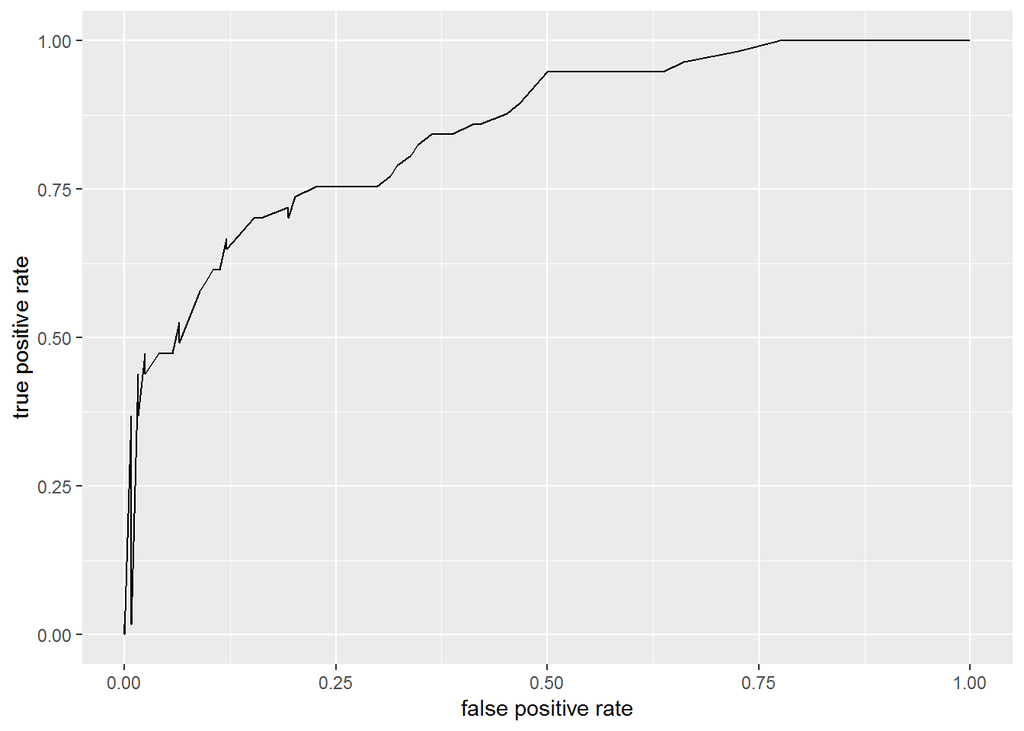

```r
calc.roc()[1]
```

**AUC**

```r
print(paste('AUC = ', calc.roc()[2]))
```

```
## [1] "AUC =  0.848896434634974"
```

# Compare results with caret packages

Investigate the caret packages with same functionalities as the functions generated above. Apply the caret functions to the dataset, and compare the results from those generated using the functions just created.

```r
library(caret)
confusionMatrix(as.factor(input.df$scored.class), as.factor(input.df$class), positive='1' )
```

```
## Confusion Matrix and Statistics
##
##           Reference
## Prediction   0   1
##          0 119  30
##          1   5  27
##
##                Accuracy : 0.8066
##                  95% CI : (0.7415, 0.8615)
##     No Information Rate : 0.6851
##     P-Value [Acc > NIR] : 0.0001712
##
##                   Kappa : 0.4916
##
##  Mcnemar's Test P-Value : 4.976e-05
##
##             Sensitivity : 0.4737
##             Specificity : 0.9597
##          Pos Pred Value : 0.8438
##          Neg Pred Value : 0.7987
##              Prevalence : 0.3149
##          Detection Rate : 0.1492
##    Detection Prevalence : 0.1768
##       Balanced Accuracy : 0.7167
##
##        'Positive' Class : 1
##
```

```r
sensitivity(as.factor(input.df$scored.class), as.factor(input.df$class), positive = 1)
```

```
## [1] 0.4736842
```

```r
specificity(as.factor(input.df$scored.class), as.factor(input.df$class), negative=0)
```

```
## [1] 0.9596774
```

We can see that above results from caret package calls matches exactly with our own function call. No difference is identified between results obtained from caret package and our own function call for important metrics like confusionmatrix, sensitivity and specificity

# Compare pROC curve

Investigate the pROC package. Use it to generate an ROC curve for the data set. How do the results compare with your own functions?

```r
library(pROC)
```

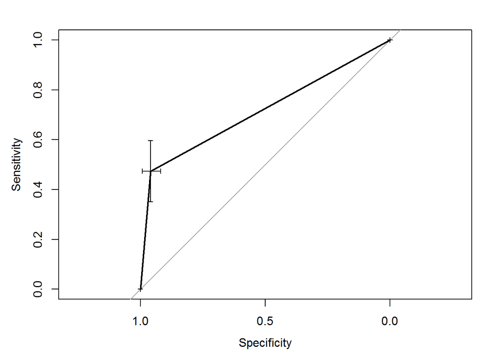

```r
roccurve = roc(input.df$class, input.df$scored.class, ci=TRUE, of="thresholds")
plot.roc(roccurve)
```

```r
auc(roccurve)
```

```
## Area under the curve: 0.7167
```

ROC obtained from pROC package looks little diffrent than ROC obtained from our own function. Area under curve is also slightly different. AUC returned from our own function is 0.84 and AUC returned from pROC package is 0.71

ROC plot obtained from our own function after tweaking threshold increments

```r
calc.roc = function()
{
  library(ggplot2)
  threshold = seq(0,1,0.5)
  class = input.df$class
  spec = c()
  sens = c()
  for(t in threshold)
  {
    scored.class = ifelse(input.df$scored.probability > t, 1, 0)
    df = data.frame(class = class, scored.class = scored.class)

    metrics.df = create.metrics(df[,'class'], df[,'scored.class'])
    spec = c(spec, calc.specificity(metrics.df))
    sens = c(sens, calc.sensitivity(metrics.df))
  }

  plt = ggplot2::qplot(1-spec, sens, xlim = c(0, 1), ylim = c(0, 1),
    xlab = "false positive rate", ylab = "true positive rate", geom='line')
   auc = simple_auc(sens, 1-spec)
   return (list(plt, auc))
}

lst = calc.roc()
```

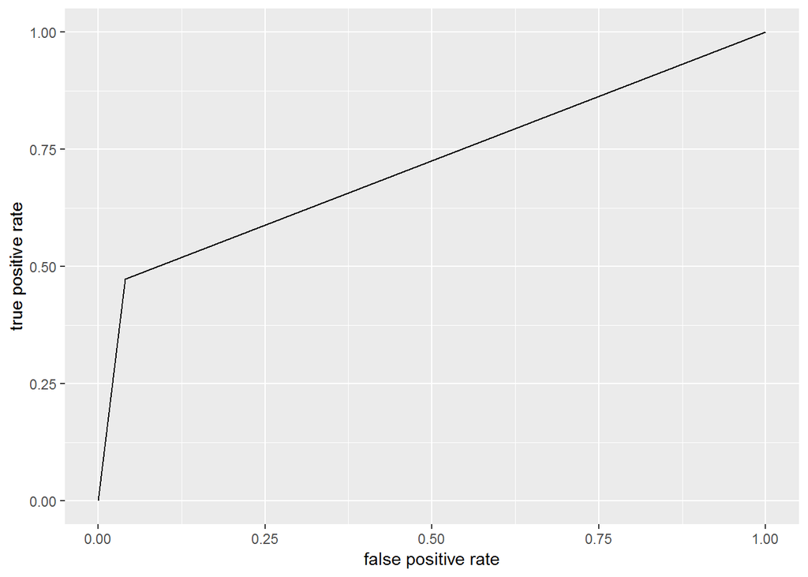

```r
lst[1]
```

AUC value obtained from our own function after tweaking threshold increments

```r
lst[2]
```

```
## [[1]]
## [1] 0.7166808
```